# OIL & GAS PRODUCTION - Text Mining Accident Reports

### This project analyzes worker accidents based on the summary reports provided by Occupational Safety and Health Administration (OSHA) and classified according to NAICS system.

## Outline:

The following are the steps required in performing the necessary analysis on the textual corpus of accident reports. Each of these steps further contain multiple tasks which are discussed in detail under their respective sections.

### 1. Data Acquisition

### 2. Text Preprocessing

### 3. Text Structuring

### 4. Text Mining

### 5. Advanced Analytics

### 6. Interactive Interface

## 1. Data Acquisition

The datasets are obtained from "osha.gov" website. Each accident report contains the **Summary** along with **Report ID**, **Event Date** and **Degree**. The last column **Degree** explains whether the accident resulted in a fatality or hospitalization of the victim. This feature can become useful (as a dependent variable) for text classification.

### Importing Data into Python Environment

There are two data files for different naics codes, we will import them both into a pandas dataframe and later combine their rows to be sorted by date.

```python
import pandas as pd

#read in the data files
ncs_21311_df = pd.read_csv('data/naics_21311_data.csv', sep = ',', header=0, parse_dates = True, na_values="")
ncs_237120_df = pd.read_csv('data/naics_237120_data.csv', sep = ',', header=0, parse_dates = True, na_values="")

dfs = [ncs_21311_df,ncs_237120_df]
raw_data =  pd.concat(dfs,  ignore_index=True)   #combine the two dataframes
raw_data.Event_Date = pd.to_datetime(raw_data.Event_Date)
raw_data.sort_values(by='Event_Date', inplace = True) #sort by event date
raw_data.reset_index(drop = True, inplace = True) #reset index from 0
```

Lets have a look into the data and its columns to observe any content of interest.

```python
raw_data.head()
```

|  | Report_ID | Event_Date | Age | Nature | Summary | Degree |
| --- | --- | --- | --- | --- | --- | --- |
| 0 | 830500 | 2013-01-03 | 49.0 | Concussion | At approximately 10:27 a.m. on January 3, 2013... | Fatality |
| 1 | 627700 | 2013-01-04 | 32.0 | Concussion | At approximately 4:15 p.m. on January 4, 2013,... | Fatality |
| 2 | 950647 | 2013-01-07 | NaN | Concussion | At approximately 11:00 a.m. on January 7, 2013... | Hospitalized injury |
| 3 | 854910 | 2013-01-09 | NaN | Other | On January 9, 2013, Employee #1, employed by a... | Fatality |
| 4 | 653510 | 2013-01-10 | NaN | Other | On January 10, 2013, Employee #1 was working o... | Fatality |

**Creating Time field:** The dataset has 417 rows and 6 columns. Each summary report begins with a phrase that contains the **time** when the accident happened. Not all reports contain time, but most of them have it. It can be of some use while performing time based analytics/prediction in future. Keeping the **time field** in a separate column will be convenient for testing correlation rather than including it in the report summary. So, we will split our report text to create a new time column in the dataframe.

```python
df = raw_data #add data to a temporary dataframe
""" All rows contain date-year, so split based on year in string.
For str.split() method specify the pattern as 1st argument,
We only need one split to happen - which is the 2nd argument,
expand=True returns a dataframe with 2 columns"""
tmp = df.Summary.str.split(" 20\d+", n=1, expand=True)

raw_data['Time'] = tmp[0]
raw_data['Summary'] = tmp[1]
raw_data = raw_data[['Report_ID', 'Event_Date', 'Time', 'Age', 'Nature', 'Summary', 'Degree']]
raw_data.tail()
```

|  | Report_ID | Event_Date | Time | Age | Nature | Summary | Degree |
| --- | --- | --- | --- | --- | --- | --- | --- |
| 412 | 950647 | 2017-12-04 | At 11:40 a.m. on December 4, | 21.0 | Fracture | , an employee was standing on the roof of a b... | Hospitalized injury |
| 413 | 627700 | 2017-12-21 | At 10:45 a.m. on December 21, | 35.0 | Fracture | , an employee was performing oil and gas work... | Fatality |
| 414 | 316400 | 2017-12-28 | At 1:00 p.m. on December 28, | 44.0 | Other | , an employee was standing outside his truck ... | Fatality |
| 415 | 627700 | 2017-12-30 | At 11:00 a.m. on December 30, | 28.0 | Fracture | , an employee was near a loading station when... | Fatality |
| 416 | 627700 | 2017-12-31 | At 9:30 a.m. on December 31, | 50.0 | Other | , an employee was preparing transport trucks ... | Fatality |

**Verifying Summary field:** Now we have the columns structured by time string and summary report text string. Although we need to clean the **Time** column to have just the time. As the summary strings are split based on a pattern, there can be some reports which do not adhere to that pattern and result in erroneous splitting. We will verify the Summary and Time strings for any missing values and correct them. Then we will make a copy of the **Summary** column to preprocess the text.

```python
print(f'Missing Values\nTime:', raw_data['Time'].isnull().sum(), f'\nSummary:', raw_data['Summary'].isnull().sum())
smry = raw_data['Summary']
print(f'\nMissing Rows in Summary column\n',smry[smry.isnull() == True])
```

```
Missing Values
Time: 0
Summary: 6

Missing Rows in Summary column
 16     None
31     None
173    None
247    None
263    None
317    None
Name: Summary, dtype: object
```

So, there are no missing values in Time but 6 in Summary column. Let's take a look at one of these rows to get an idea for how to fix them.

```python
print(raw_data.iloc[[16][:]])
```

```
    Report_ID Event_Date                                               Time  \
16     653510 2013-02-28  On February 28, Southwest Transportation Drive...

    Age Nature Summary    Degree
16  NaN  Other    None  Fatality
```

Looks like there is no year info in the string and hence the whole report is copied into Time column. We need to make a copy of the Time field string into the six missing Summary rows.

```python
rows = smry[smry.isnull() == True].index
for r in rows:
    raw_data.iloc[r,5] = raw_data.iloc[r,2]

print(f'\nSummary:', raw_data['Summary'].isnull().sum()) # Now lets check for any missing values
```

```
Summary: 0
```

**Clean Time Field** : The time column consists of text string which needs to be transformed to contain only the time information in an appropriate format. So, the strings needs to be sliced and converted to a datetime format. Then the time accuracy should be reduced to hour of day.

```python
# Time content is to be extracted from string and modify into a suitable format for coversion into time field
raw_data.Time = raw_data.Time.str.extract('(\d+:\d+ \w.\w.)') #select time based on regex
raw_data.Time = raw_data.Time.str.upper() #convert to uppercase
raw_data.Time = raw_data.Time.str.replace(".", "", n=-1)  #remove periods
raw_data.Time = pd.to_datetime(raw_data.Time, errors='coerce', format='%I:%M %p')  #convert to time
```

```python
from datetime import datetime, timedelta
def hour_rounder(t):
    # Rounds to nearest hour by adding a timedelta hour if minute >= 30
    return (t.replace(second=0, microsecond=0, minute=0, hour=t.hour)
               +timedelta(hours=t.minute//30))

raw_data.Time = raw_data.Time.apply(lambda i: hour_rounder(i) if str(i)!="NaT" else i)
raw_data.Time = raw_data.Time.dt.hour
raw_data.Time = raw_data.Time.astype('category')
```

The missing values of Summary column are now filled and we shall now make a copy of the **Summary** column to perform text preprocessing

```python
reports = raw_data['Summary']
reports.head()
```

```
0    , Employee #1 was connecting a  tanker truck t...
1    , Employee #1 was working on an  oil gas drill...
2    , Employee #1 was driving a Kubota (Model Numb...
3    , Employee #1, employed by an oil and gas pipe...
4    , Employee #1 was working on a rig. The brakes...
Name: Summary, dtype: object
```

## 2. Text Preprocessing

Preprocessing is an important yet time-consuming process in analyzing textual data. It is vital because we need to convert human readable text into machine readable format which involves several steps with multiple tools or packages. Rather than importing all packages at the beginning, for now I will import each of them where they are used in their respective cells.

### Text Normalization

We will start with Text Normalization which includes:

- **converting all letters to lower or upper case**
- **converting numbers into words or removing numbers**
- **removing punctuations, accent marks and other diacritics**
- **removing white spaces**
- **expanding abbreviations**
- **removing stop words, sparse terms, and particular words**

Depending on our needs and nature of the data some of these steps might be redundant. We can remove or add some steps as we seem fit to not lose any important details in the data.

#### Convert text to lowercase

```python
reports = reports.str.lower()
reports[3] #peek at a report
```

```
', employee #1, employed by an oil and gas pipeline contractor, was working on a pipeline construction project. he was setting a 40-foot section of 12-inch pipe into the bending machine. the machine started to slide on the frozen ground. the employee wrapped his arm around the pipe to prevent the ma…
```

#### Remove numbers

Generally numbers are not relevant for text analysis as it can be more difficult to extract context or meaning from numbers than from words. In our report, we can observe that the numbers used indicate time and date which is already provided in a separate field if we need them. The last line in the report contains vital information that "three employees are killed" in word form, thus we are not discarding any useful data.

```python
reports = reports.str.replace("\d+", "", n=-1)
reports[3] #peek at a report
```

```
', employee #, employed by an oil and gas pipeline contractor, was working on a pipeline construction project. he was setting a -foot section of -inch pipe into the bending machine. the machine started to slide on the frozen ground. the employee wrapped his arm around the pipe to prevent the machine…
```

#### Remove Punctuation

We can use the `re` regex and `string` library to select and remove any symbols like [!”#$%&’()*+,-./:;<=>?@[]^_`{|}~]:

```python
import re
import string  # Along with importing string, we are also using the 're' Regex library
reports = reports.str.replace('[%s]' % re.escape(string.punctuation), '', n=-1)
reports[3] #peek at a report
```

```
' employee  employed by an oil and gas pipeline contractor was working on a pipeline construction project he was setting a foot section of inch pipe into the bending machine the machine started to slide on the frozen ground the employee wrapped his arm around the pipe to prevent the machine from sli…
```

#### Remove whitespaces

We will use the pandas `str.strip()` method to remove ant leading or trailing whitespaces and `re.sub` method from Regex to remove any duplicate whitespaces between words.

```python
reports = reports.str.strip()
reports = reports.str.replace(' +', ' ',n=-1)
reports[3]
```

```
'employee employed by an oil and gas pipeline contractor was working on a pipeline construction project he was setting a foot section of inch pipe into the bending machine the machine started to slide on the frozen ground the employee wrapped his arm around the pipe to prevent the machine from slidi…
```

#### Tokenize to remove stopwords

Tokenization is the process of splitting the given text into smaller pieces called tokens. Stop words (or commonly occurring words) should be removed from the text data as they do not provide any value and also makes our word matrix much sparse later. For this purpose, we can either create a list of stopwords ourselves or we can use predefined libraries. Here we'll use `nltk` library which contains all basic stopwords in English language. Apart from these words we can also remove some specific words by creating a word set.

```python
import nltk
"""
If python gives out error for not finding some subpackages,
running these code lines may help:
nltk.download('stopwords')
nltk.download('punkt')
"""
from nltk.corpus import stopwords
from nltk.tokenize import word_tokenize

# tokenize
word_tokens = reports.apply(lambda r: word_tokenize(r))
word_tokens.head()
```

```
0    [employee, was, connecting, a, tanker, truck, ...
1    [employee, was, working, on, an, oil, gas, dri...
2    [employee, was, driving, a, kubota, model, num...
3    [employee, employed, by, an, oil, and, gas, pi...
4    [employee, was, working, on, a, rig, the, brak...
Name: Summary, dtype: object
```

#### Removing Stopwords and Common words:

Apart from the common language stopwords explained above there are other kinds of words not useful for the analysis. For example these words can be names of months or any common words highly used but not excluded by the stopwords library. We will first remove known stopwords and common words and then check the data for most frequently occuring words.

```python
# For now we will remove basic stopwords and month names from the tokens
rmv_words = {'january', 'february', 'march', 'april','may','june','july','august','september','october','november','december', 'am', 'pm', 'however', 'first', 'one', 'two', 'three', 'five'}
stop_words = set(stopwords.words('english'))
stop_words = stop_words.union(rmv_words)
word_tokens = word_tokens.apply(lambda t: [i for i in t if not i in stop_words])
word_tokens.head()
```

```
0    [employee, connecting, tanker, truck, barrel, ...
1    [employee, working, oil, gas, drilling, rig, s...
2    [employee, driving, kubota, model, number, rtv...
3    [employee, employed, oil, gas, pipeline, contr...
4    [employee, working, rig, brakes, drawworks, pr...
Name: Summary, dtype: object
```

Now check the data for ten most frequent words and justify whether we need to remove or retain them.

```python
freq = word_tokens.values.flatten().tolist()
freq = pd.Series(item for sublist in freq for item in sublist)
print(freq.value_counts()[:10])
print(len(freq.value_counts()))
```

```
employee     1224
pipe          185
killed        153
truck         147
struck        147
rig           126
head          118
employees     116
well          101
fell           95
dtype: int64
2666
```

The above words are all related to the accidents and we cannot immediately discard any of them. We need to observe how they are related to form relationships and if some of them are not adding value we can then remove them.

#### Removing rare words

As we have seen common words, it is more important to check rare words as well. Because each word is a column in the sparse matrix and if a word is rare it mostly contains null values, thus adding complexity while developing a model for prediction or classification. Ignoring terms that have a document frequency lower than a given threshold can help generalization and prevent overfitting, we need to limit ourselves to the set of values that aid to show strong associations. So, to remove the sparse terms we need to set up a threshold, and to calculate an ideal threshold we need to look into the distribution of the word frequencies.

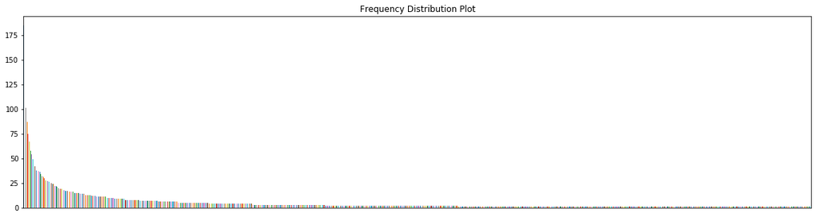

```python
import matplotlib.pyplot as plt

dst = freq.value_counts()[1:] # exclude first value, it impairs detail in plot
dst.plot.bar(figsize=(20,5), title="Frequency Distribution Plot")
ax1 = plt.axes()
x_axis = ax1.axes.get_xaxis()
x_axis.set_visible(False)
plt.show()
plt.close()
```

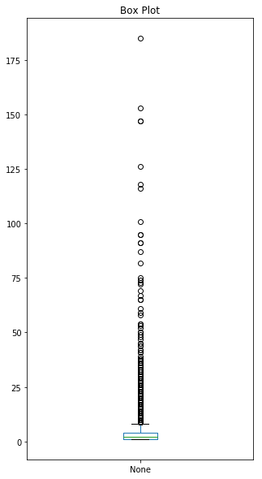

```python
dst.plot.box(figsize=(5,10), title="Box Plot")
plt.show()
plt.close()
```

As expected all rare words occupied the distribution which has an upper limit around 10. So, we will remove all rare which have repeat less than 10 times in the entire corpus.

```python
rare_words = freq.value_counts()[freq.value_counts() < 10]
rare_words = list(rare_words.index)
len(rare_words)
```

```
2361
```

The sparse matrix to be created is reduced close to 10% of its initial size. This makes it convenient to build a time and space efficient model that can generalize well. If necessary we can always trim down the model later based on its performance.

```python
# Remove words from word tokens
word_tokens = word_tokens.apply(lambda t: [i for i in t if not i in rare_words])
```

### Stemming

Stemming is a process of reducing words to their word stem, base or root form (for example, books — book, looked — look). The main two algorithms are **Porter** stemming algorithm (removes common morphological and inflexional endings from words) and **Lancaster** stemming algorithm (a more aggressive stemming algorithm).

We will try both Porter and Lancaster Stemmers again from `nltk` library and see which of these produce better results.

```python
from nltk.stem import PorterStemmer
stemmer= PorterStemmer()
stm_tkns = word_tokens.apply(lambda t: [stemmer.stem(word) for word in t])
stm_tkns.head()
```

[output not shown]

```python
from nltk.stem import LancasterStemmer
stemmer= LancasterStemmer()
stm_tkns = word_tokens.apply(lambda t: [stemmer.stem(word) for word in t])
stm_tkns.head()
```

[output not shown]

Compare the output to the original tokens, the resulting words from both the stemmers are not quite satisfactory. For many of the words the last characters are discarded and the resulting words are not meaningful and neither are actual words of English language. Hence we will try to lemmatize, which is a similar process to stemming. But for lemmatization to work effectively we will need the part of speech of the words. So we will first tag our words with their parts of speech.

### Part of speech (POS) Tagging

Part-of-speech tagging aims to assign parts of speech to each word of a given text (such as nouns, verbs, adjectives, and others) based on its definition and its context.

```python
# We will use the nltk package method to create tags
pos_tags = word_tokens.apply(lambda t: nltk.pos_tag(t))
print(pos_tags.head(),'\n\n', pos_tags[0])
```

```
0    [(employee, NN), (tanker, NN), (truck, NN), (t...
1    [(employee, NN), (working, VBG), (oil, NN), (g...
2    [(employee, NN), (driving, VBG), (number, NN),...
3    [(employee, NN), (employed, VBN), (oil, NN), (...
4    [(employee, NN), (working, VBG), (rig, NN), (d...
Name: Summary, dtype: object

 [('employee', 'NN'), ('tanker', 'NN'), ('truck', 'NN'), ('tank', 'JJ'), ('water', 'NN'), ('oil', 'NN'), ('well', 'RB'), ('hose', 'JJ'), ('connection', 'NN'), ('used', 'VBN'), ('torch', 'NN'), ('heat', 'NN'), ('hose', 'JJ'), ('connection', 'NN'), ('tank', 'NN'), ('hose', 'JJ'), ('explosion', 'NN'), …
```

We obtained POS tags for all of our words, but they are in what called as a Penn Treebank format. For the `nltk`'s lemmatizer function to work we need the tags in a Wordnet format. Therefore I created a small mapper function to convert Penn tags to Wordnet tags below.

```python
# part is a dictionary containing the Penn to Wordnet mapping as key, value pairs
part = {
    'N' : 'n',
    'V' : 'v',
    'J' : 'a',
    'S' : 's',
    'R' : 'r'
}


def convert_tag(penn_tag):
    """
    convert_tag() accepts the **first letter** of a Penn part-of-speech tag,
    then uses a dict lookup to convert it to the appropriate WordNet tag.
    """
    if penn_tag in part.keys():
        return part[penn_tag]
    else:
        # other parts of speech will be tagged as nouns
        return 'n'
```

```python
wordnet_tags = pos_tags.apply(lambda p: [(word, convert_tag(tag[0])) for word, tag in p])
print(wordnet_tags.head(), '\n\n', wordnet_tags[0])
```

```
0    [(employee, n), (tanker, n), (truck, n), (tank...
1    [(employee, n), (working, v), (oil, n), (gas, ...
2    [(employee, n), (driving, v), (number, n), (nu...
3    [(employee, n), (employed, v), (oil, n), (gas,...
4    [(employee, n), (working, v), (rig, n), (drill...
Name: Summary, dtype: object

 [('employee', 'n'), ('tanker', 'n'), ('truck', 'n'), ('tank', 'a'), ('water', 'n'), ('oil', 'n'), ('well', 'r'), ('hose', 'a'), ('connection', 'n'), ('used', 'v'), ('torch', 'n'), ('heat', 'n'), ('hose', 'a'), ('connection', 'n'), ('tank', 'n'), ('hose', 'a'), ('explosion', 'n'), ('occurred', 'v'),…
```

The POS tags are now converted into Wordnet format and we can input these now to the lemmatizer function.

### Lemmatization

The aim of lemmatization, like stemming, is to reduce inflectional forms to a common base form. As opposed to stemming, lemmatization does not simply chop off inflections. Instead it uses lexical knowledge bases to get the correct base forms of words.

```python
# download if 'wordnet' not in nltk
nltk.download('wordnet')
```

```
True
```

```python
from nltk.stem import WordNetLemmatizer
lemmatizer=WordNetLemmatizer()

lmt_word_tkns = wordnet_tags.apply(lambda w: [lemmatizer.lemmatize(word[0], word[1][0]) for word in w])
print(lmt_word_tkns.head())
```

```
0    [employee, tanker, truck, tank, water, oil, we...
1    [employee, work, oil, gas, drilling, rig, onto...
2    [employee, drive, number, number, number, truc...
3    [employee, employ, oil, gas, pipeline, work, p...
4    [employee, work, rig, drill, rig, fail, block,...
Name: Summary, dtype: object
```

```python
# Compare original words and lemmatized words
cmp_df = pd.DataFrame({'Original':word_tokens[0], 'Lemmatized':lmt_word_tkns[0]})
cmp_df
```

|  | Original | Lemmatized |
| --- | --- | --- |
| 0 | employee | employee |
| 1 | tanker | tanker |
| 2 | truck | truck |
| 3 | tank | tank |
| 4 | water | water |
| 5 | oil | oil |
| 6 | well | well |
| 7 | hose | hose |
| 8 | connection | connection |
| 9 | used | use |
| 10 | torch | torch |
| 11 | heat | heat |
| 12 | hose | hose |
| 13 | connection | connection |
| 14 | tank | tank |
| 15 | hose | hose |
| 16 | explosion | explosion |
| 17 | occurred | occur |
| 18 | employee | employee |
| 19 | killed | kill |

Finally the words are now reduced at a sufficient level to their base form. If we observe the words, *employee* turned out to be an important word, because each time *employee* is used the words following employee tell a story. However the above table is token list comparision for one document, the words for all documents need to be verified for duplicates and overwrite them with base words manually.

```python
freq = lmt_word_tkns.values.flatten().tolist()
freq = pd.Series(item for sublist in freq for item in sublist)
all_terms = freq.value_counts()
all_terms = all_terms.index
print(sorted(list(all_terms)))
len(all_terms)
```

```
['access', 'admit', 'air', 'amputate', 'amputated', 'amputation', 'another', 'approximately', 'area', 'arm', 'around', 'assembly', 'assist', 'attach', 'attached', 'attack', 'attempt', 'attempted', 'away', 'back', 'backhoe', 'bag', 'bags', 'basket', 'battery', 'beam', 'become', 'bed', 'begin', 'blew'…
```

```
310
```

There are several words with extension to their base form, for example there are three words 'amputate', 'amputation', 'amputated' which are an extended from 'amputate'.

This problem can be handled in three steps:

1. Select similar words into a python dict
2. Create a mapper function to replace words
3. Execute the function and verify tokens

```python
# Create a python dictionary
rpl_str = { 'amputate' : ['amputated','amputation'],
            'attach' : ['attached'],
            'attempt' : ['attempted'],
            'bag' : ['bags'],
            'blow' : ['blew'],
            'bolt' : ['bolts'],
            'break' : ['broken'],
            'catch' : ['caught'],
            'cause' : ['causing'],
            'collapse' : ['collapsed'],
            'connect' : ['connection','connected'],
            'coworker' : ['coworkers'],
            'crush': ['crushing','crushed'],
            'death' : ['dead','die','died'],
            'drill' : ['driller','drilling'],
            'employee' : ['employ'],
            'excavate' : ['excavation','excavator'],
            'explosion' : ['explode'],
            'fall' : ['fell'],
            'find' : ['found'],
            'fracture' : ['fractured'],
            'heat' : ['heater'],
            'hospital' : ['hospitalize','hospitalized'],
            'ignite' : ['ignited'],
            'inch' : ['inches'],
            'kill' : ['killing','killed'],
            'leg' : ['legs'],
            'lift' : ['lifted'],
            'load' : ['loaded'],
            'location' : ['locate'],
            'low' : ['lower'],
            'occur' : ['occurred'],
            'operate' : ['operation','operator','operating','operated'],
            'pipe' : ['pip','piping','pipeline','piped'],
            'place' : ['placed','placing'],
            'pressure' : ['pressurize','pressurized'],
            'provide' : ['provided'],
            'pull' : ['pulled'],
            'receive' : ['received'],
            'suffer' : ['suffered'],
            'sustain' : ['sustained'],
            'strike' : ['striking'],
            'tank' : ['tanker','tanks'],
            'throw' : ['thrown'],
            'tube' : ['tubing'],
            'transport' : ['transported','transporting'],
            'treat' : ['treating','treated','treatment'],
            'use' : ['used','using'],
            'weld' : ['welding','welded']
          }
```

```python
new_word_tokens = lmt_word_tkns
new_word_tokens = new_word_tokens.apply(lambda t: ' '.join(t))
new_word_tokens = new_word_tokens.apply(lambda t: ' '+t+' ')

for k,v in rpl_str.items():
    for i in range(len(v)):
        new_word_tokens = new_word_tokens.str.replace(v[i]+" ", k+" ", n=-1)

new_word_tokens = new_word_tokens.apply(lambda t: t.strip())
new_word_tokens = new_word_tokens.apply(lambda t: t.split(' '))
```

```python
freq = new_word_tokens.values.flatten().tolist()
freq = pd.Series(item for sublist in freq for item in sublist)
all_terms = freq.value_counts()
all_terms = all_terms.index
print(sorted(list(all_terms)))
len(all_terms)
```

```
['access', 'admit', 'air', 'amputate', 'another', 'approximately', 'area', 'arm', 'around', 'assembly', 'assist', 'attach', 'attack', 'attempt', 'away', 'back', 'backhoe', 'bag', 'basket', 'battery', 'beam', 'become', 'bed', 'begin', 'block', 'blow', 'blunt', 'board', 'body', 'bolt', 'boom', 'bop', …
```

```
247
```

A unique set of 310 words are now reduced to 247 words due to the mapper function. It implies 20% of redundancy will be reduced in the sparse matrix without loss of value. The next stage is to structurize word tokens for analysis and extract interesting features to detect patterns in the data.

## 3. Text Structuring (Feature Engineering)

### Word Embeddings:

This section deals with text structuring and advanced processing of accident reports data. The text until now is in unstructured format and to perform any analytics/modeling it should be converted to a numerical format. Word Embeddings are the texts converted into numbers and there may be different numerical representations of the same text. A Word Embedding format generally tries to map a word using a dictionary to a vector.

Word embeddings can be either of frequency based or prediction based. Prominent techniques from both categories will be used to structurize the data, which will be further evaluated to perform appropriate analytics.

### Term Frequency

This is the most obvious technique to find out the relevance of a word in a document. The more frequent a word is, the more relevance the word holds in the context. It is the ratio of number of times the word appears in a document compared to the total number of words in that document. Term frequency increases as the number of occurrences of that word within the document increases.

```python
# Most Frequent Terms
freq = new_word_tokens.values.flatten().tolist()
freq = pd.Series(item for sublist in freq for item in sublist)
mft = freq.value_counts()[:30]
mft = ' '.join(mft.index)
```

We have extracted the top 30 frequent words, now let's plot a wordcloud to view them. This gives us a peek into the theme of words among all records.

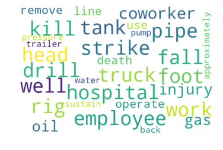

```python
# Word Cloud of Top 30 Most Frequent Terms
from wordcloud import WordCloud
wordcloud = WordCloud(width=600, height=400, min_font_size=10, max_font_size=60, background_color='white').generate(mft)
plt.imshow(wordcloud, interpolation="bilinear")
plt.axis("off")
plt.show()
plt.close()
```

**Now, we will move forward to generate a Term-Frequency sparse matrix using the `scikit-learn` library.**

```python
from sklearn.feature_extraction.text import TfidfVectorizer
cnvrt_to_str = new_word_tokens.apply(lambda t: ' '.join(t))
tfidf = TfidfVectorizer(use_idf=False, analyzer = 'word')
tf_matrix = tfidf.fit_transform(cnvrt_to_str)
tf_matrix
```

```
<417x247 sparse matrix of type '<class 'numpy.float64'>'
	with 6220 stored elements in Compressed Sparse Row format>
```

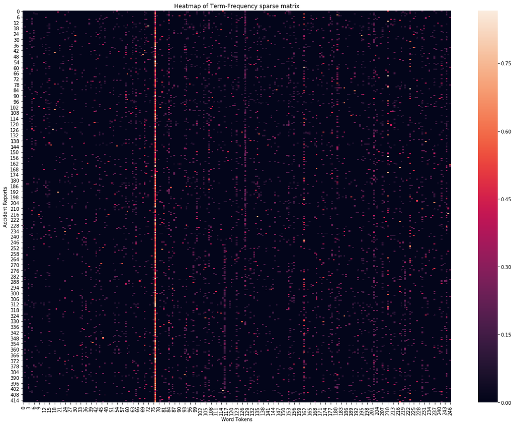

```python
import seaborn as sns
fig,ax = plt.subplots(figsize=(20,15))
sns.heatmap(tf_matrix.todense(), ax=ax)
plt.title("Heatmap of Term-Frequency sparse matrix")
plt.xlabel("Word Tokens")
plt.ylabel("Accident Reports")
plt.show()
plt.close()
```

### Term Frequency - Inverse Document Frequency

In information retrieval, TFIDF short for term frequency–inverse document frequency, is a numerical statistic that is intended to reflect how important a word is to a document in a collection or corpus. It is often used as a weighting factor in searches of information retrieval, text mining, and user modeling. The tf–idf value increases proportionally to the number of times a word appears in the document and is offset by the number of documents in the corpus that contain the word, which helps to adjust for the fact that some words appear more frequently in general. Tf–idf is one of the most popular term-weighting schemes today; 83% of text-based recommender systems in digital libraries use tf–idf.

```python
# Generate a tf-idf matrix
tfidf = TfidfVectorizer(use_idf=True, analyzer = 'word')
tfidf_matrix = tfidf.fit_transform(cnvrt_to_str)
tfidf_matrix
```

```
<417x247 sparse matrix of type '<class 'numpy.float64'>'
	with 6220 stored elements in Compressed Sparse Row format>
```

Similar to the term frequency matrix lets also plot a heatmap to find the differences between TF and TF-IDF matrices.

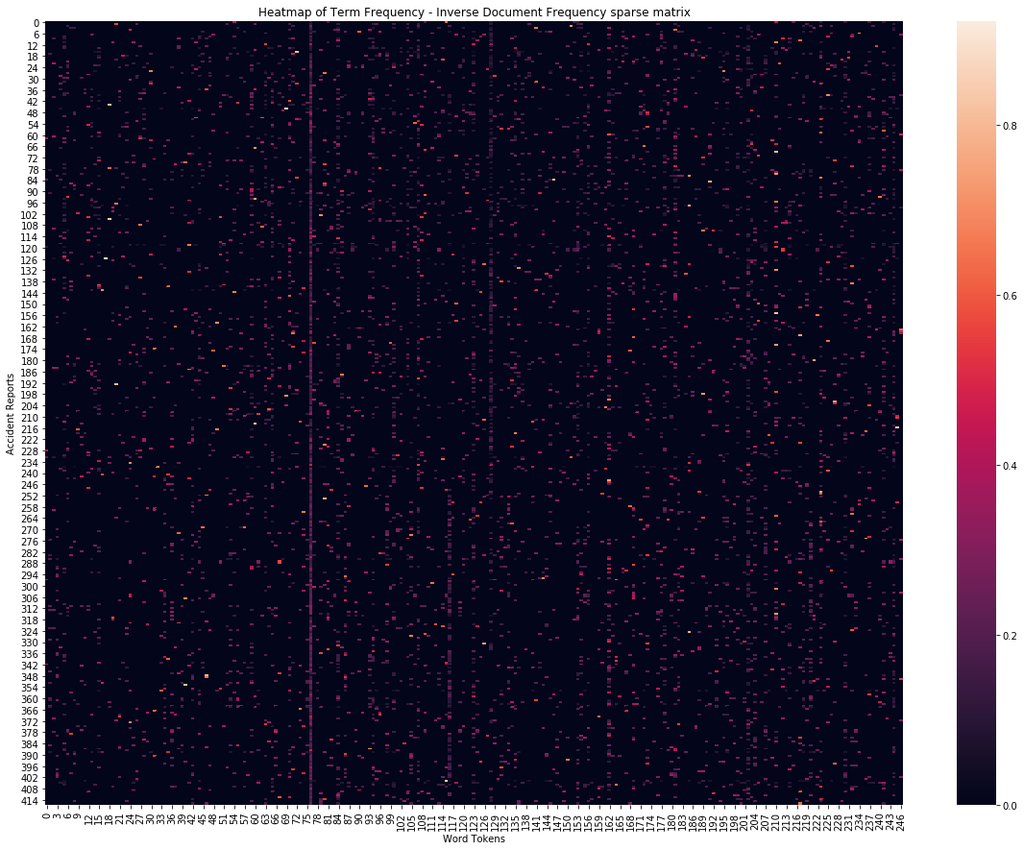

```python
import seaborn as sns
fig,ax = plt.subplots(figsize=(20,15))
sns.heatmap(tfidf_matrix.todense(), ax=ax)
plt.title("Heatmap of Term Frequency - Inverse Document Frequency sparse matrix")
plt.xlabel("Word Tokens")
plt.ylabel("Accident Reports")
plt.show()
plt.close()
```

A quick difference to note is weightage for the word 'employee' is penalized as it occurs commonly between all documents. Similarly few other common words are penalized and several words weightage is increased. Overall there are subtle improvements in the sparsity of TF-IDF matrix. The next step is identify the top weighted words in the tf-idf matrix and compare them to the most frequent words to observe any differences.

```python
# Create pandas DataFrame from scipy csr matrix format
tfidf_df = pd.DataFrame(tfidf_matrix.toarray(), columns = tfidf.get_feature_names())
```

```python
tfidf_df.head()
# rows are accident reports
# columns are word tokens
```

|  | access | admit | air | amputate | another | approximately | area | arm | around | assembly | ... | water | wear | weight | weld | well | wire | within | work | worker | wrench |
| --- | --- | --- | --- | --- | --- | --- | --- | --- | --- | --- | --- | --- | --- | --- | --- | --- | --- | --- | --- | --- | --- |
| 0 | 0.0 | 0.0 | 0.0 | 0.0 | 0.0 | 0.0 | 0.000000 | 0.000000 | 0.000000 | 0.0 | ... | 0.158553 | 0.000000 | 0.0 | 0.0 | 0.139059 | 0.0 | 0.0 | 0.000000 | 0.0 | 0.0 |
| 1 | 0.0 | 0.0 | 0.0 | 0.0 | 0.0 | 0.0 | 0.000000 | 0.000000 | 0.000000 | 0.0 | ... | 0.000000 | 0.000000 | 0.0 | 0.0 | 0.000000 | 0.0 | 0.0 | 0.136513 | 0.0 | 0.0 |
| 2 | 0.0 | 0.0 | 0.0 | 0.0 | 0.0 | 0.0 | 0.157956 | 0.000000 | 0.000000 | 0.0 | ... | 0.000000 | 0.199581 | 0.0 | 0.0 | 0.000000 | 0.0 | 0.0 | 0.000000 | 0.0 | 0.0 |
| 3 | 0.0 | 0.0 | 0.0 | 0.0 | 0.0 | 0.0 | 0.000000 | 0.160697 | 0.149535 | 0.0 | ... | 0.000000 | 0.000000 | 0.0 | 0.0 | 0.000000 | 0.0 | 0.0 | 0.086359 | 0.0 | 0.0 |
| 4 | 0.0 | 0.0 | 0.0 | 0.0 | 0.0 | 0.0 | 0.000000 | 0.000000 | 0.000000 | 0.0 | ... | 0.000000 | 0.000000 | 0.0 | 0.0 | 0.000000 | 0.0 | 0.0 | 0.137406 | 0.0 | 0.0 |

5 rows × 247 columns

```python
col_agg = tfidf_df.agg("sum")
top_idf = col_agg.sort_values(ascending = False)[:30]
print(top_idf)
```

```
employee    78.401100
pipe        29.043839
kill        21.648996
tank        20.426162
truck       19.292290
strike      18.241849
fall        17.371639
rig         17.055417
head        16.987752
hospital    16.625060
work        15.782004
drill       15.144978
injury      14.947086
foot        13.928337
well        13.245622
death       12.820370
oil         12.531520
pressure    12.215698
coworker    12.042945
gas         11.631354
line        11.089583
operate     10.861539
remove      10.804709
sustain     10.674491
use         10.155615
trailer     10.123128
suffer      10.084324
pump         9.870767
water        9.686679
fracture     9.427758
dtype: float64
```

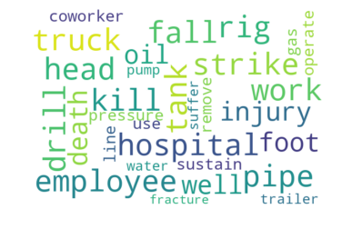

```python
# Word Cloud of Top 30 TF-IDF terms
from wordcloud import WordCloud
top_idf = ' '.join(top_idf.index)
wordcloud = WordCloud(width=600, height=400, min_font_size=10, max_font_size=60, background_color='white').generate(top_idf)
plt.imshow(wordcloud, interpolation="bilinear")
plt.axis("off")
plt.show()
plt.close()
```

```python
# Compare top 30 terms between TF and TF-IDF matrices
pd.DataFrame({'TF' : mft.split(' '),
            'TF-IDF' : top_idf.split(' ')})
```

|  | TF | TF-IDF |
| --- | --- | --- |
| 0 | employee | employee |
| 1 | pipe | pipe |
| 2 | kill | kill |
| 3 | truck | tank |
| 4 | tank | truck |
| 5 | work | strike |
| 6 | strike | fall |
| 7 | fall | rig |
| 8 | rig | head |
| 9 | hospital | hospital |
| 10 | head | work |
| 11 | foot | drill |
| 12 | drill | injury |
| 13 | well | foot |
| 14 | coworker | well |
| 15 | injury | death |
| 16 | oil | oil |
| 17 | gas | pressure |
| 18 | operate | coworker |
| 19 | death | gas |
| 20 | remove | line |
| 21 | use | operate |
| 22 | line | remove |
| 23 | pressure | sustain |
| 24 | approximately | use |
| 25 | back | trailer |
| 26 | trailer | suffer |
| 27 | sustain | pump |
| 28 | pump | water |
| 29 | water | fracture |

### Bag of Words:

Bag of Words (BoW) refers to the representation of text which describes the presence of words within the text data. The intuition behind this is that two similar text fields will contain similar kind of words, and will therefore have a similar bag of words.

```python
from sklearn.feature_extraction.text import CountVectorizer
bow = CountVectorizer(ngram_range=(1,1),analyzer = "word")
train_bow = bow.fit_transform(cnvrt_to_str)
bow_df = pd.DataFrame(train_bow.toarray(), columns = bow.get_feature_names())
bow_df.head()
```

|  | access | admit | air | amputate | another | approximately | area | arm | around | assembly | ... | water | wear | weight | weld | well | wire | within | work | worker | wrench |
| --- | --- | --- | --- | --- | --- | --- | --- | --- | --- | --- | --- | --- | --- | --- | --- | --- | --- | --- | --- | --- | --- |
| 0 | 0 | 0 | 0 | 0 | 0 | 0 | 0 | 0 | 0 | 0 | ... | 0 | 0 | 0 | 0 | 1 | 0 | 0 | 0 | 0 | 0 |
| 1 | 0 | 0 | 0 | 0 | 0 | 0 | 0 | 0 | 1 | 0 | ... | 0 | 0 | 0 | 0 | 0 | 0 | 0 | 0 | 0 | 0 |
| 2 | 0 | 0 | 0 | 0 | 0 | 0 | 0 | 0 | 0 | 0 | ... | 0 | 0 | 0 | 0 | 0 | 0 | 0 | 0 | 0 | 0 |
| 3 | 0 | 0 | 0 | 0 | 0 | 0 | 0 | 0 | 0 | 0 | ... | 0 | 0 | 0 | 0 | 0 | 0 | 0 | 0 | 0 | 0 |
| 4 | 0 | 0 | 0 | 0 | 0 | 0 | 0 | 0 | 0 | 0 | ... | 0 | 0 | 0 | 0 | 0 | 0 | 0 | 0 | 0 | 0 |

5 rows × 247 columns

Bag of words is a preliminary technique yet the understanding it is essential for Continuou Bag of Words(CBOW), which is a more advanced and extended concept of Bag of Words. The methods discussed below are prediction based, in the sense that they provided probabilities to the words and proved to be state of the art for tasks like word analogies and word similarities. Another algorithm similar to CBOW in topology is Skip-Gram model, these two models together form an algorithm known as Word2Vec. Both of these models are shallow neural networks which map word(s) to the target variable which is also a word(s). Both of these techniques learn weights which act as word vector representations.

Word2Vec transcends from structurizing tokens in the form of word embeddings to buidling neural networks that can be modeled to predict multiple context based situations.

## 4. Text Mining

This section deals with mining text data by using techniques to identify patterns and trends in text data with respect to other feature variables including target variable. Text mining acts as a preparatory stage to modeling text for classification. It is exploratory in nature and hence different techniques are used for identification of intelligent information among the variables in the dataset. Initially we will begin to explore each of the variables to know its range, distribution, number of levels and if necessary transform it to be able to apply and fit to the model well.

### Event Date

```python
raw_data.Event_Date.describe()
```

```
count                     417
unique                    354
top       2017-01-04 00:00:00
freq                        3
first     2013-01-03 00:00:00
last      2017-12-31 00:00:00
Name: Event_Date, dtype: object
```

```python
# One time use - Initiate plotly
import plotly
plotly.tools.set_credentials_file(username='binti', api_key='dv1XHP8ygm00itAg9m4C')
```

```python
import plotly.offline as off
import plotly.graph_objs as go

off.init_notebook_mode(connected=False)

data = [dict(
  x = raw_data['Event_Date'],
  autobinx = False,
  autobiny = True,
  #marker = dict(color = 'rgb(68, 68, 68)'),
  name = 'date',
  type = 'histogram',
  xbins = dict(
    end = '2017-12-31',
    size = 'M1',
    start = '2013-01-01'
  )
)]

layout = dict(
  #paper_bgcolor = 'rgb(240, 240, 240)',
  #plot_bgcolor = 'rgb(240, 240, 240)',
  title = '<b>Oil & Gas Industry Accidents</b>',
  xaxis = dict(
    title = '',
    type = 'date'
  ),
  yaxis = dict(
    title = 'Accident Count',
    type = 'linear'
  ),
  updatemenus = [dict(
        x = 0.1,
        y = 1.15,
        xref = 'paper',
        yref = 'paper',
        yanchor = 'top',
        active = 1,
        showactive = True,
        buttons = [
        dict(
            args = ['xbins.size', 'D1'],
            label = 'Day',
            method = 'restyle',
        ), dict(
            args = ['xbins.size', 'M1'],
            label = 'Month',
            method = 'restyle',
        ), dict(
            args = ['xbins.size', 'M3'],
            label = 'Quater',
            method = 'restyle',
        ), dict(
            args = ['xbins.size', 'M6'],
            label = 'Half Year',
            method = 'restyle',
        ), dict(
            args = ['xbins.size', 'M12'],
            label = 'Year',
            method = 'restyle',
        )]
  )]
)

off.iplot({'data': data,'layout': layout}, validate=False)
```

[interactive chart not shown]

As the Event_Date field is niether numerical nor categorical we cannot use it directly for our analysis. And date itself is a very granular field which makes it further difficult for analysis. Hence new columns must be derived from date that are of relevance to the data.

```python
def add_datepart(df, fldname):
    fld = df[fldname]
    targ_pre = re.sub('[Dd]ate$','',fldname)
    for n in ('Year','Month','Week','Day','Dayofweek','Is_month_end','Is_month_start','Is_quarter_end','Is_quarter_start','Is_year_end','Is_year_start'):
        df[targ_pre+n] = getattr(fld.dt, n.lower())
        df[targ_pre+'Elapsed'] = (fld - fld.min()).dt.days

add_datepart(raw_data, 'Event_Date')
```

**Day of Week vs Degree**

```python
dydg_df = pd.DataFrame(raw_data.Event_Date.dt.day_name())
dydg_df['Degree'] = raw_data.Degree
dydg_df = pd.DataFrame(dydg_df.groupby(['Event_Date','Degree']).size().reset_index(name='count'))
dydg_df = dydg_df.pivot(index='Event_Date', columns='Degree', values='count')
dydg_df.reset_index(inplace=True)
cats = [ 'Monday', 'Tuesday', 'Wednesday', 'Thursday', 'Friday', 'Saturday', 'Sunday']
from pandas.api.types import CategoricalDtype
cat_type = CategoricalDtype(categories=cats, ordered=True)
dydg_df.Event_Date = dydg_df.Event_Date.astype(cat_type)
dydg_df.sort_values('Event_Date', inplace=True)
```

```python
trace1 = go.Bar(
    x=dydg_df.Event_Date,
    y=dydg_df.Fatality,
    name='Fatality'
)
trace2 = go.Bar(
    x=dydg_df.Event_Date,
    y=dydg_df['Hospitalized injury'],
    name='Hospitalized Injury'
)
trace3 = go.Bar(
    x=dydg_df.Event_Date,
    y=dydg_df['Non Hospitalized injury'],
    name='Non Hospitalized Injury'
)

data = [trace1, trace2, trace3]
layout = go.Layout(
    barmode='group',
    title = '<b>Day of Week vs Degree</b>',
    yaxis = dict(
    title = 'Accident Count',
    type = 'linear'
    ),
    legend=dict(x=0, y=1.1, orientation='h')
)

fig = go.Figure(data=data, layout=layout)
off.iplot(fig, validate=False)
```

[interactive chart not shown]

**Month vs Degree**

```python
mdg = pd.DataFrame(raw_data.Event_Date.dt.month_name())
mdg['Degree'] = raw_data.Degree
mdg = pd.DataFrame(mdg.groupby(['Event_Date','Degree']).size().reset_index(name='count'))
mdg = mdg.pivot(index='Event_Date', columns='Degree', values='count')
mdg.reset_index(inplace=True)
cats = ['January', 'February', 'March', 'April','May','June', 'July', 'August','September', 'October', 'November', 'December']
from pandas.api.types import CategoricalDtype
cat_type = CategoricalDtype(categories=cats, ordered=True)
mdg.Event_Date = mdg.Event_Date.astype(cat_type)
mdg.sort_values('Event_Date', inplace=True)
```

```python
trace1 = go.Bar(
    x=mdg.Event_Date,
    y=mdg.Fatality,
    name='Fatality'
)
trace2 = go.Bar(
    x=mdg.Event_Date,
    y=mdg['Hospitalized injury'],
    name='Hospitalized Injury'
)
trace3 = go.Bar(
    x=mdg.Event_Date,
    y=mdg['Non Hospitalized injury'],
    name='Non Hospitalized Injury'
)

data = [trace1, trace2, trace3]
layout = go.Layout(
    barmode='group',
    title = '<b>Month vs Degree</b>',
    xaxis=dict(tickangle=-45),
    yaxis = dict(
    title = 'Accident Count',
    type = 'linear'
    ),
    legend=dict(x=0, y=1.1, orientation='h')
)

fig = go.Figure(data=data, layout=layout)
off.iplot(fig, validate=False)
```

[interactive chart not shown]

### Time field

Time field is modified to contain only hourly info which accounts to 24 hours per day. That still might be needed to reduced to 4 levels for better performance of the model

**Time vs Degree:**

```python
hdg = pd.DataFrame({'Time':raw_data.Time, 'Degree':raw_data.Degree})
hdg = pd.DataFrame(hdg.groupby(['Time','Degree']).size().reset_index(name='count'))
hdg = hdg.pivot(index='Time', columns='Degree', values='count')
hdg.reset_index(inplace=True)
```

```python
trace1 = go.Bar(
    x=hdg.Time,
    y=hdg.Fatality,
    name='Fatality'
)
trace2 = go.Bar(
    x=hdg.Time,
    y=hdg['Hospitalized injury'],
    name='Hospitalized Injury'
)
trace3 = go.Bar(
    x=hdg.Time,
    y=hdg['Non Hospitalized injury'],
    name='Non Hospitalized Injury'
)

data = [trace1, trace2, trace3]
layout = go.Layout(
    barmode='group',
    title = '<b>Hour of Day vs Degree</b>',
    yaxis = dict(
    title = 'Accident Count',
    type = 'linear'
    ),
    legend=dict(x=0, y=1.1, orientation='h')
)

fig = go.Figure(data=data, layout=layout)
off.iplot(fig, validate=False)
```

[interactive chart not shown]

It is clearly obvious that most accidents occur during 8am to 5pm period. There is a broader distinction between degree levels in the first half of the day. Instead of having 24 levels it helps to reduce the levels to four for every 6 hours. We will create a new variable Hour_Range for 7am-12pm, 1pm-6pm, 7pm-12am, 1am-6pm

```python
raw_data['Hour_Range'] = raw_data.Time.astype('int32', errors='ignore')

def cnvrt_hour(val):
    if val>=1 and val<=6:
        return "1am-6pm"
    elif val>=7 and val<=12:
        return "7am-12pm"
    elif val>=13 and val<=18:
        return "1pm-6pm"
    else:
        return "7pm-12am"

raw_data.Hour_Range = raw_data.Hour_Range.apply(lambda i: cnvrt_hour(i))
raw_data.Hour_Range = raw_data.Hour_Range.astype('category')
```

```python
hrdg = pd.DataFrame({'Hour_Range':raw_data.Hour_Range, 'Degree':raw_data.Degree})
hrdg = pd.DataFrame(hrdg.groupby(['Hour_Range','Degree']).size().reset_index(name='count'))
hrdg = hrdg.pivot(index='Hour_Range', columns='Degree', values='count')
hrdg.reset_index(inplace=True)
cats = ["1am-6pm", "7am-12pm", "1pm-6pm", "7pm-12am"]
cat_type = CategoricalDtype(categories=cats, ordered=True)
hrdg.Hour_Range =hrdg.Hour_Range.astype(cat_type)
hrdg.sort_values('Hour_Range', inplace=True)
```

```python
trace1 = go.Bar(
    x=hrdg.Hour_Range,
    y=hrdg.Fatality,
    name='Fatality'
)
trace2 = go.Bar(
    x=hrdg.Hour_Range,
    y=hrdg['Hospitalized injury'],
    name='Hospitalized Injury'
)
trace3 = go.Bar(
    x=hrdg.Hour_Range,
    y=hrdg['Non Hospitalized injury'],
    name='Non Hospitalized Injury'
)

data = [trace1, trace2, trace3]
layout = go.Layout(
    barmode='group',
    title = '<b>Hour of Day vs Degree</b>',
    yaxis = dict(
    title = 'Accident Count',
    type = 'linear'
    ),
    legend=dict(x=0, y=1.1, orientation='h')
)

fig = go.Figure(data=data, layout=layout)
off.iplot(fig, validate=False)
```

[interactive chart not shown]

### Age and Nature fields

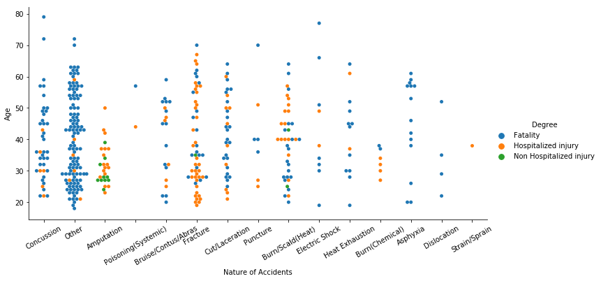

```python
import seaborn as sns
g = sns.catplot(x='Nature', y='Age', hue='Degree', kind='swarm', data=raw_data, height=5, aspect=2)
g.set_axis_labels("Nature of Accidents","Age")
g.set_xticklabels(rotation=30)
```

## 5. Advanced Analytics

### Preliminary Model Building

**Data Setup**

```python
# Combine all predictor variables and prep data
dfmod = pd.concat([raw_data.iloc[:,[3,4]],raw_data.iloc[:,7:], tfidf_df], axis=1)
dfmod.Nature = dfmod.Nature.astype('category').cat.as_ordered()
dfmod.Nature = dfmod.Nature.cat.codes+1
dfmod.Hour_Range = dfmod.Hour_Range.cat.codes+1
dfmod.Age = dfmod.Age.fillna(dfmod.Age.median())
y = raw_data.Degree
dfmod.head()
```

|  | Age | Nature | Hour_Range | Event_Year | Event_Elapsed | Event_Month | Event_Week | Event_Day | Event_Dayofweek | Event_Is_month_end | ... | water | wear | weight | weld | well | wire | within | work | worker | wrench |
| --- | --- | --- | --- | --- | --- | --- | --- | --- | --- | --- | --- | --- | --- | --- | --- | --- | --- | --- | --- | --- | --- |
| 0 | 49.0 | 6 | 3 | 2013 | 0 | 1 | 1 | 3 | 3 | False | ... | 0.158553 | 0.000000 | 0.0 | 0.0 | 0.139059 | 0.0 | 0.0 | 0.000000 | 0.0 | 0.0 |
| 1 | 32.0 | 6 | 2 | 2013 | 1 | 1 | 1 | 4 | 4 | False | ... | 0.000000 | 0.000000 | 0.0 | 0.0 | 0.000000 | 0.0 | 0.0 | 0.136513 | 0.0 | 0.0 |
| 2 | 38.0 | 6 | 3 | 2013 | 4 | 1 | 2 | 7 | 0 | False | ... | 0.000000 | 0.199581 | 0.0 | 0.0 | 0.000000 | 0.0 | 0.0 | 0.000000 | 0.0 | 0.0 |
| 3 | 38.0 | 12 | 4 | 2013 | 6 | 1 | 2 | 9 | 2 | False | ... | 0.000000 | 0.000000 | 0.0 | 0.0 | 0.000000 | 0.0 | 0.0 | 0.086359 | 0.0 | 0.0 |
| 4 | 38.0 | 12 | 4 | 2013 | 7 | 1 | 2 | 10 | 3 | False | ... | 0.000000 | 0.000000 | 0.0 | 0.0 | 0.000000 | 0.0 | 0.0 | 0.137406 | 0.0 | 0.0 |

5 rows × 262 columns

**Splitting data into Train and Test sets**

```python
from sklearn.model_selection import train_test_split
from sklearn.naive_bayes import MultinomialNB

X_train, X_test, y_train, y_test = train_test_split(dfmod, y, test_size=0.25, random_state=90)
X_train.shape, y_train.shape, X_test.shape, y_test.shape
```

```
((312, 262), (312,), (105, 262), (105,))
```

**Building Naive Bayes Classifier**

```python
m = MultinomialNB()
m.fit(X_train, y_train)
m.score(X_train, y_train)
print('Accuracy of Naive Bayes Classifier on training set: {:.2f}'
     .format(m.score(X_train, y_train)))
print('Accuracy of Naive Bayes Classifier on test set: {:.2f}'
     .format(m.score(X_test, y_test)))
```

```
Accuracy of Naive Bayes Classifier on training set: 0.73
Accuracy of Naive Bayes Classifier on test set: 0.77
```

We can observe that the test set accuracy of Naive Bayes classifier is higher than training set. We thus need to perform cross validation and fit the model to different samples. Another observation is the overall accuracy for Naive Bayes is moderate. Lets try out different models with cross validation to choose best model

**Model Selection**

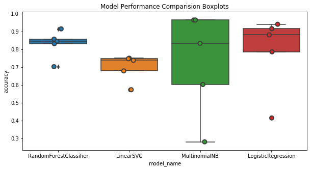

```python
from sklearn.linear_model import LogisticRegression
from sklearn.ensemble import RandomForestClassifier
from sklearn.svm import LinearSVC
from sklearn.model_selection import cross_val_score
import warnings; warnings.simplefilter('ignore')

models = [
    RandomForestClassifier(n_estimators=200, max_depth=3, random_state=0),
    LinearSVC(),
    MultinomialNB(),
    LogisticRegression(random_state=0),
]

CV = 5
cv_df = pd.DataFrame(index=range(CV * len(models)))
entries = []
features = dfmod
labels = raw_data.Degree.astype('category').cat.as_ordered()

for model in models:
  model_name = model.__class__.__name__
  accuracies = cross_val_score(model, features, labels, scoring='accuracy', cv=CV)
  for fold_idx, accuracy in enumerate(accuracies):
    entries.append((model_name, fold_idx, accuracy))

cv_df = pd.DataFrame(entries, columns=['model_name', 'fold_idx', 'accuracy'])

import seaborn as sns
f, ax = plt.subplots(figsize=(10, 5))
sns.boxplot(x='model_name', y='accuracy', data=cv_df)
sns.stripplot(x='model_name', y='accuracy', data=cv_df,
              size=8, jitter=True, edgecolor="gray", linewidth=2)
plt.title('Model Performance Comparision Boxplots')
plt.show()
plt.close()
```

```python
print("Mean Accuracies")
print(cv_df.groupby('model_name').accuracy.mean())
print('\nMedian Accuracies')
print(cv_df.groupby('model_name').accuracy.median())
```

```
Mean Accuracies
model_name
LinearSVC                 0.697365
LogisticRegression        0.787488
MultinomialNB             0.728960
RandomForestClassifier    0.830144
Name: accuracy, dtype: float64

Median Accuracies
model_name
LinearSVC                 0.738095
LogisticRegression        0.880952
MultinomialNB             0.833333
RandomForestClassifier    0.845238
Name: accuracy, dtype: float64
```

Random Forest and Logistic Regression perform better than the other two classifiers, with Random Forest having a slight advantage with a mean accuracy of around 83%. But if we look at the median accuracies Logistic Regression outperforms all others. In an ideal situation there should not be large deviations between mean and medians. As we can observe there are also outliers which are affecting models (this could possible be due to the low distribution of 'Non Hospitalized Injuries' level in the Degree field).

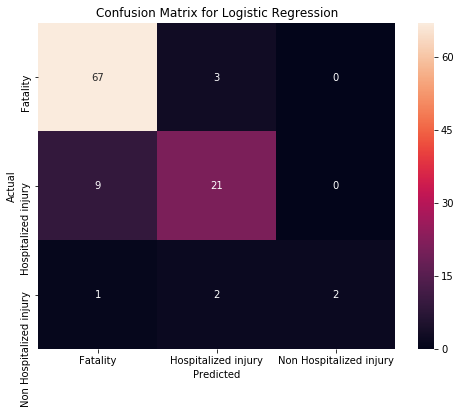

```python
model = LogisticRegression(random_state=0)
X_train, X_test, y_train, y_test, indices_train, indices_test = train_test_split(features, labels, df.index, test_size=0.25, random_state=0)
model.fit(X_train, y_train)
y_pred = model.predict(X_test)
from sklearn.metrics import confusion_matrix
conf_mat = confusion_matrix(y_test, y_pred)
fig, ax = plt.subplots(figsize=(8,6))
sns.heatmap(conf_mat, annot=True, fmt='d',
            xticklabels=labels.cat.categories, yticklabels=labels.cat.categories)
plt.ylabel('Actual')
plt.xlabel('Predicted')
plt.title('Confusion Matrix for Logistic Regression')
plt.show()
plt.close()
```

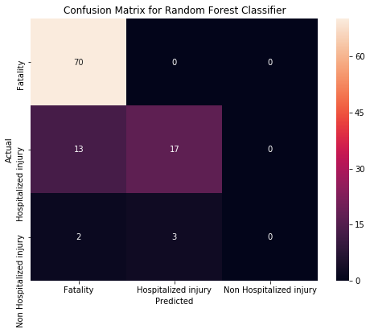

```python
model = RandomForestClassifier(n_estimators=200, max_depth=3, random_state=0, n_jobs=-1)
X_train, X_test, y_train, y_test, indices_train, indices_test = train_test_split(features, labels, df.index, test_size=0.25, random_state=0)
model.fit(X_train, y_train)
y_pred = model.predict(X_test)
from sklearn.metrics import confusion_matrix
conf_mat = confusion_matrix(y_test, y_pred)
fig, ax = plt.subplots(figsize=(8,6))
sns.heatmap(conf_mat, annot=True, fmt='d',
            xticklabels=labels.cat.categories, yticklabels=labels.cat.categories)
plt.ylabel('Actual')
plt.xlabel('Predicted')
plt.title('Confusion Matrix for Random Forest Classifier')
plt.show()
plt.close()
```